# ASSIGNMENT 1-1

[figure not shown]

### Initialization of useful matrix

For the correct computation of $P(s'|s,a)$, it is useful to write $P(s'|s,a)$ as a 3rd-order tensor, where the 3rd dimension corresponds to $P(s'|s,a=a_i)$.  
In general, the definition of $P(s'|s,a)$ as a 3rd-order tensor is an abuse of notation because not all $P(s'|s,a=a_i)$ are defined for all states, because some action can be not abilitated, and for this reason, the sum of probabilities along the rows is not equal to 1.  
Bearing this in mind, for simplicity, the solution of this assignment uses this abuse of notation.  
The compact form of $P(s'|s,a \sim {\pi}_i)$ is equivalent to a 2nd-order tensor, where the single element of $P(s'|s,a \sim \pi_i)$ can be extracted from the general form $P(s'|s,a)$.  
An equivalent analysis can be done for $R(s,a)$, which is generally equivalent to a 2nd-order tensor, but the expected value of reward function following $\pi_i$, namely $\mathbf{E}\left[R(s,a)\right]$, is a column vector.

```
State transition probability matrix for pi1 is
 [[0. 1. 0. 0. 0. 0. 0. 0. 0. 0. 0. 0. 0. 0. 0. 0. 0. 0. 0. 0.]
 [0. 0. 1. 0. 0. 0. 0. 0. 0. 0. 0. 0. 0. 0. 0. 0. 0. 0. 0. 0.]
 [0. 0. 0. 1. 0. 0. 0. 0. 0. 0. 0. 0. 0. 0. 0. 0. 0. 0. 0. 0.]
 [0. 0. 0. 0. 1. 0. 0. 0. 0. 0. 0. 0. 0. 0. 0. 0. 0. 0. 0. 0.]
 [1. 0. 0. 0. 0. 0. 0. 0. 0. 0. 0. 0. 0. 0. 0. 0. 0. 0. 0. 0.]
 [0. 0. 0. 0. 0. 0. 1. 0. 0. 0. 0. 0. 0. 0. 0. 0. 0. 0. 0. 0.]
 [0. 0. 0. 0. 0. 0. 0. 1. 0. 0. 0. 0. 0. 0. 0. 0. 0. 0. 0. 0.]
 [0. 0. 0. 0. 0. 0. 0. 0. 1. 0. 0. 0. 0. 0. 0. 0. 0. 0. 0. 0.]
 [0. 0. 0. 0. 0. 0. 0. 0. 0. 1. 0. 0. 0. 0. 0. 0. 0. 0. 0. 0.]
 [1. 0. 0. 0. 0. 0. 0. 0. 0. 0. 0. 0. 0. 0. 0. 0. 0. 0. 0. 0.]
 [0. 0. 0. 0. 0. 0. 0. 0. 0. 0. 0. 1. 0. 0. 0. 0. 0. 0. 0. 0.]
 [0. 0. 0. 0. 0. 0. 0. 0. 0. 0. 0. 0. 1. 0. 0. 0. 0. 0. 0. 0.]
 [0. 0. 0. 0. 0. 0. 0. 0. 0. 0. 0. 0. 0. 1. 0. 0. 0. 0. 0. 0.]
 [0. 0. 0. 0. 0. 0. 0. 0. 0. 0. 0. 0. 0. 0. 1. 0. 0. 0. 0. 0.]
 [1. 0. 0. 0. 0. 0. 0. 0. 0. 0. 0. 0. 0. 0. 0. 0. 0. 0. 0. 0.]
 [0. 0. 0. 0. 0. 0. 0. 0. 0. 0. 0. 0. 0. 0. 0. 0. 1. 0. 0. 0.]
 [0. 0. 0. 0. 0. 0. 0. 0. 0. 0. 0. 0. 0. 0. 0. 0. 0. 1. 0. 0.]
 [0. 0. 0. 0. 0. 0. 0. 0. 0. 0. 0. 0. 0. 0. 0. 0. 0. 0. 1. 0.]
 [0. 0. 0. 0. 0. 0. 0. 0. 0. 0. 0. 0. 0. 0. 0. 0. 0. 0. 0. 1.]
 [1. 0. 0. 0. 0. 0. 0. 0. 0. 0. 0. 0. 0. 0. 0. 0. 0. 0. 0. 0.]]


State transition probability matrix for pi2 is
 [[0. 1. 0. 0. 0. 0. 0. 0. 0. 0. 0. 0. 0. 0. 0. 0. 0. 0. 0. 0.]
 [0. 0. 1. 0. 0. 0. 0. 0. 0. 0. 0. 0. 0. 0. 0. 0. 0. 0. 0. 0.]
 [0. 0. 0. 1. 0. 0. 0. 0. 0. 0. 0. 0. 0. 0. 0. 0. 0. 0. 0. 0.]
 [0. 0. 0. 0. 1. 0. 0. 0. 0. 0. 0. 0. 0. 0. 0. 0. 0. 0. 0. 0.]
 [0. 0. 0. 0. 0. 1. 0. 0. 0. 0. 0. 0. 0. 0. 0. 0. 0. 0. 0. 0.]
 [0. 0. 0. 0. 0. 0. 1. 0. 0. 0. 0. 0. 0. 0. 0. 0. 0. 0. 0. 0.]
 [0. 0. 0. 0. 0. 0. 0. 1. 0. 0. 0. 0. 0. 0. 0. 0. 0. 0. 0. 0.]
 [0. 0. 0. 0. 0. 0. 0. 0. 1. 0. 0. 0. 0. 0. 0. 0. 0. 0. 0. 0.]
 [0. 0. 0. 0. 0. 0. 0. 0. 0. 1. 0. 0. 0. 0. 0. 0. 0. 0. 0. 0.]
 [0. 0. 0. 0. 0. 0. 0. 0. 0. 0. 1. 0. 0. 0. 0. 0. 0. 0. 0. 0.]
 [0. 0. 0. 0. 0. 0. 0. 0. 0. 0. 0. 1. 0. 0. 0. 0. 0. 0. 0. 0.]
 [0. 0. 0. 0. 0. 0. 0. 0. 0. 0. 0. 0. 1. 0. 0. 0. 0. 0. 0. 0.]
 [0. 0. 0. 0. 0. 0. 0. 0. 0. 0. 0. 0. 0. 1. 0. 0. 0. 0. 0. 0.]
 [0. 0. 0. 0. 0. 0. 0. 0. 0. 0. 0. 0. 0. 0. 1. 0. 0. 0. 0. 0.]
 [0. 0. 0. 0. 0. 0. 0. 0. 0. 0. 0. 0. 0. 0. 0. 1. 0. 0. 0. 0.]
 [0. 0. 0. 0. 0. 0. 0. 0. 0. 0. 0. 0. 0. 0. 0. 0. 1. 0. 0. 0.]
 [0. 0. 0. 0. 0. 0. 0. 0. 0. 0. 0. 0. 0. 0. 0. 0. 0. 1. 0. 0.]
 [0. 0. 0. 0. 0. 0. 0. 0. 0. 0. 0. 0. 0. 0. 0. 0. 0. 0. 1. 0.]
 [0. 0. 0. 0. 0. 0. 0. 0. 0. 0. 0. 0. 0. 0. 0. 0. 0. 0. 0. 1.]
 [1. 0. 0. 0. 0. 0. 0. 0. 0. 0. 0. 0. 0. 0. 0. 0. 0. 0. 0. 0.]]
```

```
Reward matrix:
 [[ 0.  0. nan]
 [ 0.  0. nan]
 [ 0.  0. nan]
 [ 0.  0. nan]
 [ 0.  0.  5.]
 [ 0.  0. nan]
 [ 0.  0. nan]
 [ 0.  0. nan]
 [ 0.  0. nan]
 [ 0.  0. 20.]
 [ 0.  0. nan]
 [ 0.  0. nan]
 [ 0.  0. nan]
 [ 0.  0. nan]
 [ 0.  0. 45.]
 [ 0.  0. nan]
 [ 0.  0. nan]
 [ 0.  0. nan]
 [ 0.  0. nan]
 [ 0. nan 80.]]
Expected reward for policy 1 is:
 [[ 0.]
 [ 0.]
 [ 0.]
 [ 0.]
 [ 5.]
 [ 0.]
 [ 0.]
 [ 0.]
 [ 0.]
 [20.]
 [ 0.]
 [ 0.]
 [ 0.]
 [ 0.]
 [45.]
 [ 0.]
 [ 0.]
 [ 0.]
```

[output cut: 8 more lines]

```
 [ 0.]
 [ 0.]
 [ 0.]
 [ 0.]
 [ 0.]
 [ 0.]
 [ 0.]
 [ 0.]
 [ 0.]
 [ 0.]
 [ 0.]
 [ 0.]
 [ 0.]
 [ 0.]
 [80.]]
```

## 1.a

[figure not shown]

## Compute exact value function (matrix form)

FORMULA  
$V^{\pi} = (I - \gamma P^{\pi})^{-1} R^{\pi}$

```
Inverse not possible for Gamma = 1
Inverse not possible for Gamma = 1
```

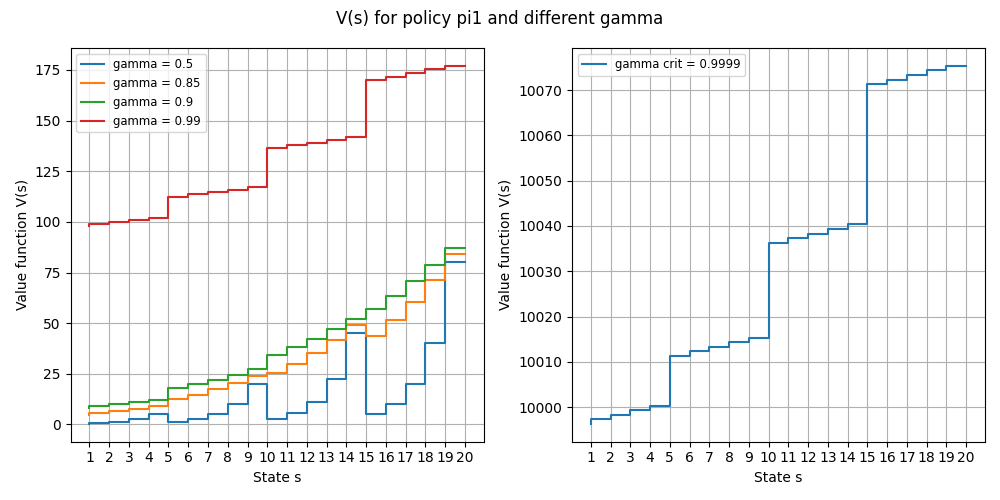

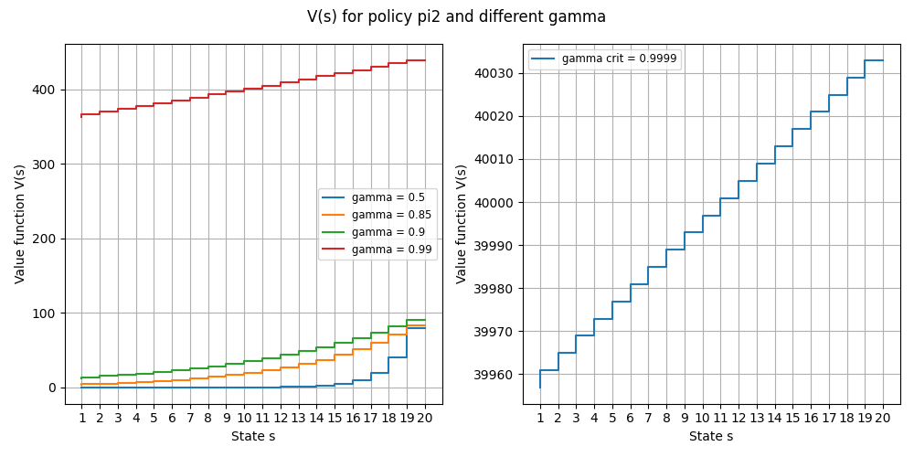

### Check with Bellman expectation equation

$V(s) = R^{\pi} + \gamma \cdot P^{\pi} \cdot V(s)$

```
Norm error between value function that satisfies in bellman expectation equation and value function computed in closed form:

POLICY 1

Norm error: 0.0  gamma:  0.5
Norm error: 6.198883e-06  gamma:  0.85
Norm error: 5.722046e-06  gamma:  0.9
Norm error: 3.5785033e-05  gamma:  0.99


POLICY 2

Norm error: 0.0  gamma:  0.5
Norm error: 7.1684344e-06  gamma:  0.85
Norm error: 8.203817e-06  gamma:  0.9
Norm error: 7.47525e-05  gamma:  0.99
```

## 1.b

[figure not shown]

### Compute exact action-value function following $\pi_i$

FORMULA

$Q(s,a) = \mathbf{E}\left[R(s,a) + \gamma \cdot V^\pi(s') | P(s'|s,a)\right]$

Compute $Q(s,\pi(s))$ and compare with $V^\pi(s)$

```
POLICY 1. Norm error between action-value function and value function:

Norm error: 0.0  gamma: 0.5
Norm error: 6.198883056640625e-06  gamma: 0.85
Norm error: 5.7220458984375e-06  gamma: 0.9
Norm error: 3.578503310563974e-05  gamma: 0.99


POLICY 2. Norm error between action-value function and value function:

Norm error: 0.0  gamma: 0.5
Norm error: 7.168434422055725e-06  gamma: 0.85
Norm error: 8.203816832974553e-06  gamma: 0.9
Norm error: 7.475249731214717e-05  gamma: 0.99
```

### Visualization of matrix $Q(s,a)$, $Q(s,\pi(s))$

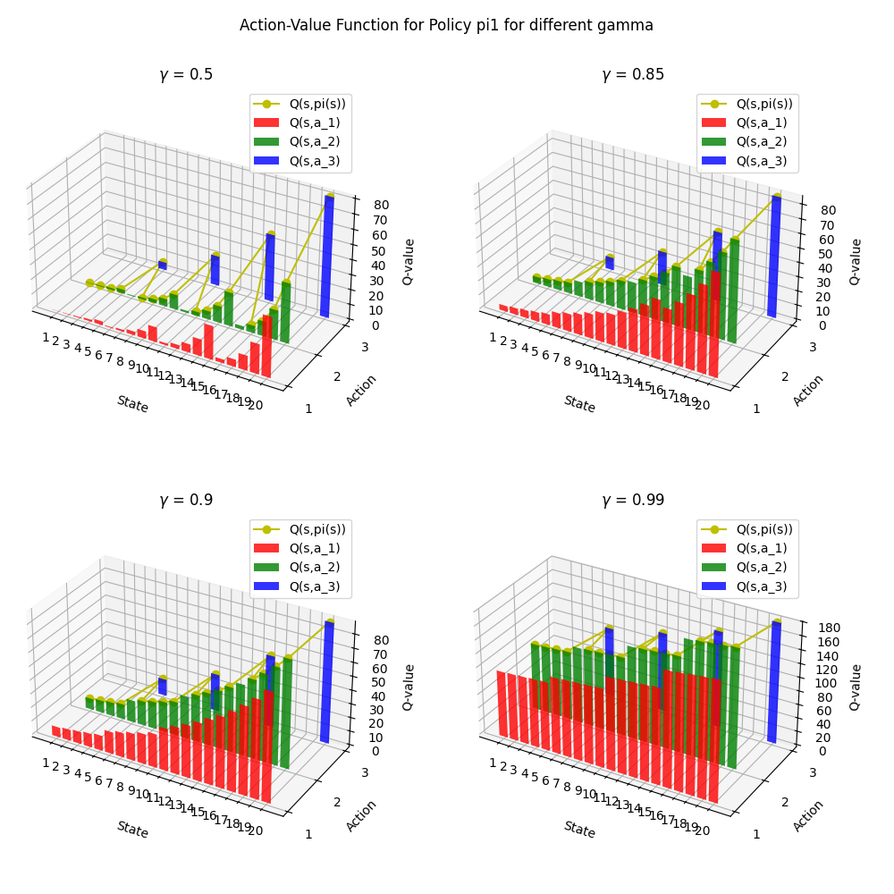

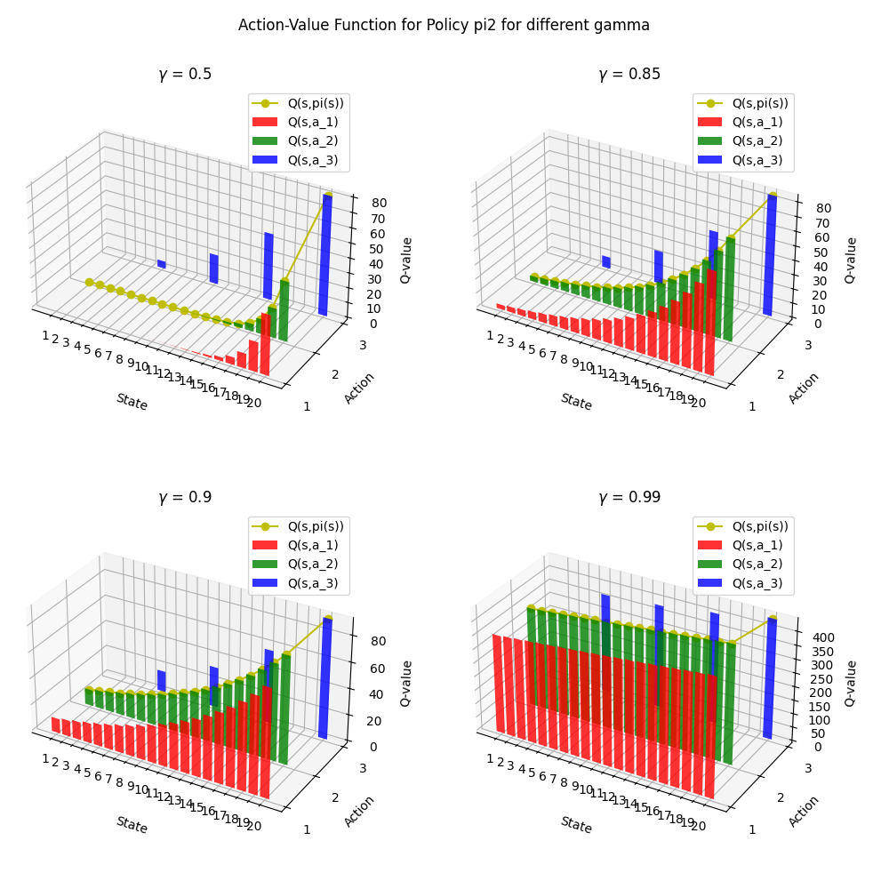

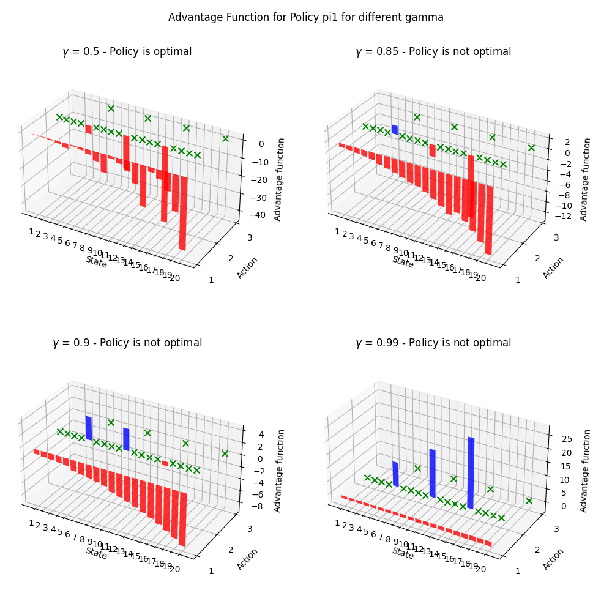

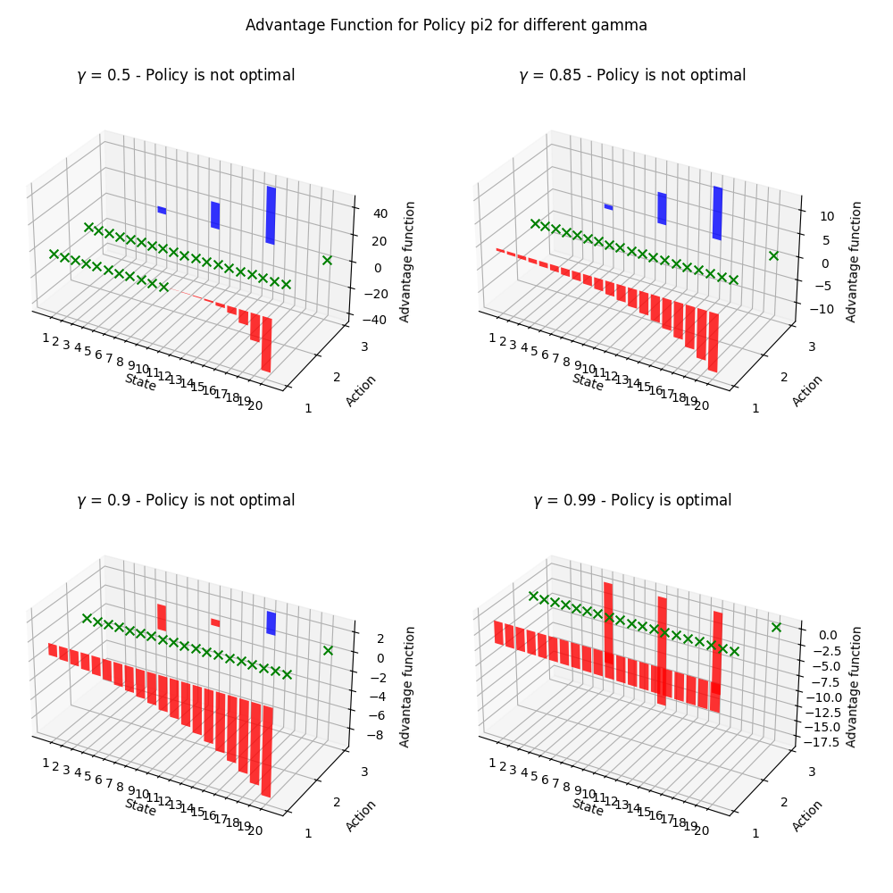

We can observe that:

- with low gamma, policy 1 is optimal.
- with high gamma, policy 2 is optimal.

In particular, higher gamma encourages the optimal policy to consider states and actions with higher rewards, even if those states are far from the current state.

## 1.c

[figure not shown]

### Compute $V^*$ by policy evaluation.

FORMULA: $V_{i+1} = R^{\pi} + \gamma \cdot P^{\pi} \cdot V_{i}$

```
Policy pi1 Evaluation Error

convergence obtained in 26 iterations with $\gamma$ 0.5 and norm error:  5.462856e-07
convergence not obtained in 1000 iterations with $\gamma$ 0.85 and norm error:  1.1121658e-05
convergence not obtained in 1000 iterations with $\gamma$ 0.9 and norm error:  9.344062e-06
convergence not obtained in 1000 iterations with $\gamma$ 0.99 and norm error:  0.019685568

Policy pi2 Evaluation Error

convergence obtained in 26 iterations with $\gamma$ 0.5 and norm error:  6.882551e-07
convergence not obtained in 1000 iterations with $\gamma$ 0.85 and norm error:  6.468134e-06
convergence not obtained in 1000 iterations with $\gamma$ 0.9 and norm error:  2.1851423e-05
convergence not obtained in 1000 iterations with $\gamma$ 0.99 and norm error:  0.07762738
```

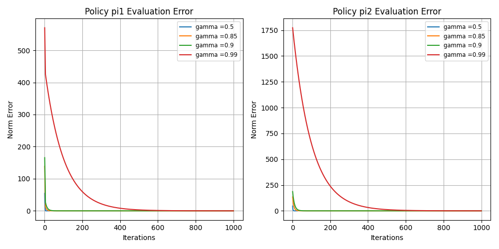

## 1.d

[figure not shown]

### Compute V* by value iteration

FORMULA:  
$V(s) = \max_{a} [R(s,a) + \gamma \cdot V(s') \vert P(s'|s,a)]$

```
convergence obtained in 25 iterations with $\gamma$ 0.5 and norm error:  6.556511e-07
Optimal action with gamma =  0.5  is:
 [1 1 1 1 2 1 1 1 1 2 1 1 1 1 2 1 1 1 1 2]
convergence obtained in 105 iterations with $\gamma$ 0.85 and norm error:  0.0
Optimal action with gamma =  0.85  is:
 [1 1 1 1 1 1 1 1 1 2 1 1 1 1 2 1 1 1 1 2]
convergence obtained in 180 iterations with $\gamma$ 0.9 and norm error:  9.536743e-07
Optimal action with gamma =  0.9  is:
 [1 1 1 1 1 1 1 1 1 1 1 1 1 1 2 1 1 1 1 2]
convergence not obtained in 1000 iterations with $\gamma$ 0.99 and norm error:  0.0018782571
Optimal action with gamma =  0.99  is:
 [1 1 1 1 1 1 1 1 1 1 1 1 1 1 1 1 1 1 1 2]
```

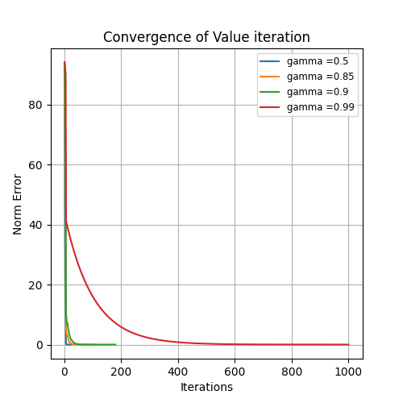

## 1.e

[figure not shown]

```
Start with Policy 1
convergence obtained in 15  iterations with $\gamma$ 0.5 and norm error:  5.3312016e-07
Optimal action for policy pi1 with gamma =  0.5  is:
 [1 1 1 1 2 1 1 1 1 2 1 1 1 1 2 1 1 1 1 2]
convergence obtained in 54  iterations with $\gamma$ 0.85 and norm error:  0.0
Optimal action for policy pi1 with gamma =  0.85  is:
 [1 1 1 1 1 1 1 1 1 2 1 1 1 1 2 1 1 1 1 2]
convergence obtained in 92  iterations with $\gamma$ 0.9 and norm error:  0.0
Optimal action for policy pi1 with gamma =  0.9  is:
 [1 1 1 1 1 1 1 1 1 1 1 1 1 1 2 1 1 1 1 2]
convergence obtained in 737  iterations with $\gamma$ 0.99 and norm error:  0.0
Optimal action for policy pi1 with gamma =  0.99  is:
 [1 1 1 1 1 1 1 1 1 1 1 1 1 1 1 1 1 1 1 2]


Start with Policy 2
convergence obtained in 16  iterations with $\gamma$ 0.5 and norm error:  5.3312016e-07
Optimal action for policy pi2 with gamma =  0.5  is:
 [1 1 1 1 2 1 1 1 1 2 1 1 1 1 2 1 1 1 1 2]
convergence obtained in 55  iterations with $\gamma$ 0.85 and norm error:  0.0
Optimal action for policy pi2 with gamma =  0.85  is:
 [1 1 1 1 1 1 1 1 1 2 1 1 1 1 2 1 1 1 1 2]
convergence obtained in 93  iterations with $\gamma$ 0.9 and norm error:  0.0
Optimal action for policy pi2 with gamma =  0.9  is:
 [1 1 1 1 1 1 1 1 1 1 1 1 1 1 2 1 1 1 1 2]
convergence obtained in 738  iterations with $\gamma$ 0.99 and norm error:  0.0
Optimal action for policy pi2 with gamma =  0.99  is:
 [1 1 1 1 1 1 1 1 1 1 1 1 1 1 1 1 1 1 1 2]
```

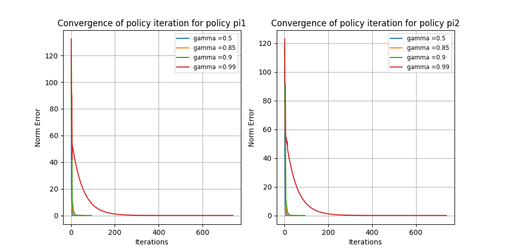